# Assignment-3

N Nedd

February 19, 2017

# Assignment

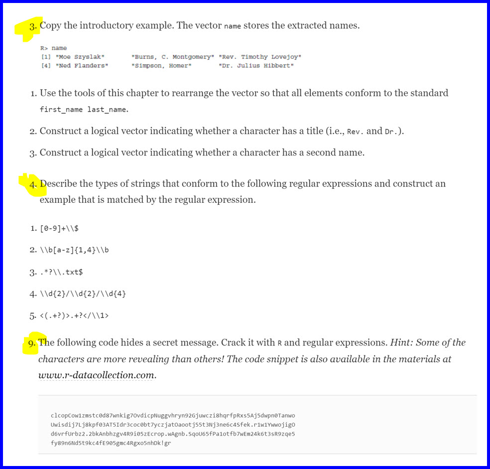

Questions

# Setup Packages

```r
if("stringr" %in% rownames(installed.packages()) == FALSE) {install.packages("stringr")}
library(stringr)
```

# Question 3

*Extract from example in book*

```r
raw_data <- "555-1239Moe Szyslak(636) 555-0113Burns, C. Montgomery555-6542Rev. Timothy Lovejoy555 8904Ned #Flanders636-555-3226Simpson, Homer5553642Dr. Julius Hibbert"

name <- unlist(str_extract_all(raw_data, "[[:alpha:]., ]{2,}"))
```

## (a)

```r
name2 <- name
#First names
for (index in 1:length(name2))
{
  #Search and extract abbreviated first names
  if (str_detect(name[index], "[A-Z]\\.")){name2[index] <- str_extract(name[index], "[A-Z]\\.")}
  #Search for and extract where the where first name is written last as in Simpson, Homer
  if(str_detect(name[index], "\\, [A-Za-z]+$")){name2[index] <- str_extract(name[index], "[A-Za-z]+$")}
  #Search for and extract where first name is written first.
  if(str_detect(name[index], "\\b[[:alpha:]]+ \\b")){name2[index] <- str_extract(name[index],"\\b[[:alpha:]]+ ")}
}
#Remove spaces in firstname
name2 <- str_trim(name2)

#Last Names
name3 <- name
for (index in 1:length(name3))
{
  #Extract those last names that are written first.
  if (str_detect(name[index], "^\\b[[:alpha:]]+\\,"))
    {name3[index] <- str_extract(name[index], "^\\b[[:alpha:]]+\\b")}
  else
    #Extract those last names that are written as the last word
    {name3[index] <- str_extract(name[index], "[A-Za-z]+$")}
}

#Combine first and last names separated by space
rearranged_name <- str_c(name2, name3, sep = " ")
rearranged_name
```

```
## [1] "Moe Szyslak"       "C. Burns"          "Timothy Lovejoy"
## [4] NA                  "Flanders Flanders" "Homer Simpson"
## [7] "Julius Hibbert"
```

## (b)

A title is denoted by at least 2 word characters followed by a fullstop

```r
has_title <- str_detect(name, "\\w{2,}\\.")
has_title
```

```
## [1] FALSE FALSE  TRUE FALSE FALSE FALSE  TRUE
```

## (c)

A second name will be assumed to be middle name (comes between the first and last name).

```r
name4 <- name
for (index in 1:length(name))
{
  #Eliminate those names with only one space - indicates only first and last name.
  if ((str_count(name[index], "\\s")) == 1)
  {
    name4[index] <- FALSE
  }
  #Eliminate those names with Titles (which is not a second name)
  else if  (str_detect(name[index], "\\w{2,}\\."))
  {
    name4[index] <- FALSE
  }
  #Anything left is considered to have a second name
  else
    name4[index] <- TRUE
}
name4 <- as.logical(name4)
name4
```

```
## [1] FALSE  TRUE FALSE FALSE  TRUE FALSE FALSE
```

# Question 4

## (a)

The expression refers to any number of consecutive digits followed immediately by a dollar sign (‘$’). Any spaces, letters or punctuation marks are not considered

```r
unlist(str_extract_all("675 837$ 30,9834$ dgag 699393 $", "[0-9]+\\$"))
```

```
## [1] "837$"  "9834$"
```

```r
str_extract("592$", "[0-9]+\\$")
```

```
## [1] "592$"
```

## (b)

The expression refers to a word that consists of 1 to 4 lower case letters

```r
unlist(str_extract_all("Mary had a little lamb, his fleece was white as snow.","\\b[a-z]{1,4}\\b" ))
```

```
## [1] "had"  "a"    "lamb" "his"  "was"  "as"   "snow"
```

```r
#The words fleece, little and white all have more than 4 letters, while Mary has a capital letter
unlist(str_extract_all("a cat in a hat", "\\b[a-z]{1,4}\\b"))
```

```
## [1] "a"   "cat" "in"  "a"   "hat"
```

## (c)

The expression refers to any lenght of text followed by .txt. .txt must be the last characters in the string. Basically returns filenames with a ‘txt’ extension.

```r
unlist(str_extract_all("marveltxt", ".*?\\.txt$"))
```

```
## character(0)
```

```r
unlist(str_extract_all("marvel.txt", ".*?\\.txt$"))
```

```
## [1] "marvel.txt"
```

## (d)

The expression refers to 2 digits followed by a / followed by 2 digits followed by / followed by four digits. Similar to the year if written in mm/dd/yyyy or dd/mm/yyyy format. This sequence can be located in any part of the string.

```r
unlist(str_extract_all("The due date for this assignment date is 19/02/2017", "\\d{2}/\\d{2}/\\d{4}"))
```

```
## [1] "19/02/2017"
```

## (e)

The expression refers a ‘<’ followed by any number of characters then ‘>’ followed by any number of characters followed by ‘<’ then any number of characters then a ‘/’ followed by a recall of the the characters between the first ‘<’ and ‘>’ then finally ‘>’. This is the pattern of a snippet of HTML Code - open tag, some text, then closing tag.

```r
unlist(str_extract_all("<H1>DATA 607 is fun!</H1>", "<(.+?)>.+?</\\1>"))
```

```
## [1] "<H1>DATA 607 is fun!</H1>"
```

# Extra Credit (Question 9)

```r
secret <- "clcopCow1zmstc0d87wnkig7OvdicpNuggvhryn92Gjuwczi8hqrfpRxs5Aj5dwpn0TanwoUwisdij7Lj8kpf03AT5Idr3coc0bt7yczjatOaootj55t3Nj3ne6c4Sfek.r1w1YwwojigOd6vrfUrbz2.2bkAnbhzgv4R9i05zEcrop.wAgnb.SqoU65fPa1otfb7wEm24k6t3sR9zqe5fy89n6Nd5t9kc4fE905gmc4Rgxo5nhDk!gr"

message <- unlist(str_extract_all(secret, "[A-Z]|[[:punct:]]"))
cat(str_c(message, collapse = ""))
```

```
## CONGRATULATIONS.YOU.ARE.A.SUPERNERD!
```